### DABUKURI

#### Dados do Imóvel

Tipo de Imóvel: **RURAL**; Uso: **ALVENARIA**;

Proprietário: **Jandenil dos Santos Costa** ; CPF: **962.624.512-34**; Endereço: **Aturaxama Ɨpe, casa nº6, Estrada Campos Elíseos, Ramal Brasileirinho, km8, Manaus, Brasil**; Comarca: **4º Registro de Imóveis de Manaus**; Área: **120m<sup>2</sup>**; Perímetro: **46m**;

Descrição: Projeto, Levantamento Topográfico, Planta e Memorial descritivo

| Marcos | Coordenadas |
| --- | --- |
| M01 | 3°0′57.07″S / 59°52′19.82″W |
| M02 | 3°0′57.23″S / 59°52′20.02″W |
| M03 | 3°0′56.81″S / 59°52′20.33″W |
| M04 | 3°0′56.66″S / 59°52′20.14″W |

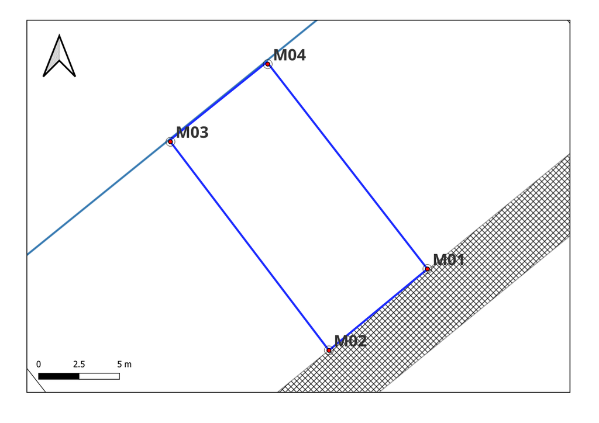

#### Limites e confrontações do terreno

**Frente (SUL)**: Frente para a Rua Aturaxama Ɨpe, Corresponde ao segmento que une os marcos M-01 (3°0′57.07″S / 59°52′19.82″W) e M-02 (3°0′57.23″S / 59°52′20.02″W), com comprimento de 8 metros.

**Lateral direita (OESTE)**: É constituída pela linha imaginária entre os marcos M-02 (3°0′57.23″S / 59°52′20.02″W) e M-03 (3°0′56.81″S / 59°52′20.33″W), com 15 metros;

**Fundos (NORTE)**: o fundo do terreno é demarcado pelos pontos M-03 (3°0′56.81″S / 59°52′20.33″W) e M-04 (3°0′56.66″S / 59°52′20.14″W), distantes 8 metros entre si.

**Lateral esquerda (LESTE)**: A linha que une os marcos M-04 (3°0′56.66″S / 59°52′20.14″W) e M-01 (3°0′57.07″S / 59°52′19.82″W) com 15 metros;

Observações:

Manaus, 29 ago 2023.

| Responsável técnica: Ivani Ferreira de Faria – Geógrafa (CREAM-AM 123456789-0) |  | Proprietário(a): Jandenil dos Santos Costa |
| --- | --- | --- |